# Current smoker

# 1 Description of DataSchema variable

The description of harmonised variable is the following:

- Short name: `current_smoking`
- Variable label: `Current smoker`
- Variable description: `Current smoker. Any type of tobacco smoking.`
- Domain: `Lifestyle and health behaviours`
- Value type: `categorical`
- Category coding:

| **Code** | **Category Label** |
| --- | --- |
| 0 | No |
| 1 | Yes |

- Category missings:

| **Code** | **Category Label** |
| --- | --- |
| 991 | CAPI/interviewer error |
| 992 | Impute |
| 993 | Disable to measure |
| 994 | Not attempt/not done |
| 995 | Does not answer |
| 996 | Not applicable |
| 997 | Refuse |
| 998 | Do not know |
| 999 | Missing |

# 2 Data process

## 2.1 England

### 2.1.1 Wave 1

#### 2.1.1.1 Study-specific variable description

| **Name** | `smoker` |
| --- | --- |
| **Label** | `whether current smoker` |
| **Table name** | `wave_1_ifs_derived_variables` |
| **Categories:** | `0 = not a current smoker` `1 = current smoker` |
| **Missings:** | `-2 = not asked` `-8 = don't know` `-9 = refuse` |
| **Description** |  |

smoker

| Sample size | Missing values |
| --- | --- |
| 12099 | 191 |

Category

|  | 0 | 1 |
| --- | --- | --- |
| Frequency | 9747.00 | 2161.00 |
| Percentage | 80.56 | 17.86 |

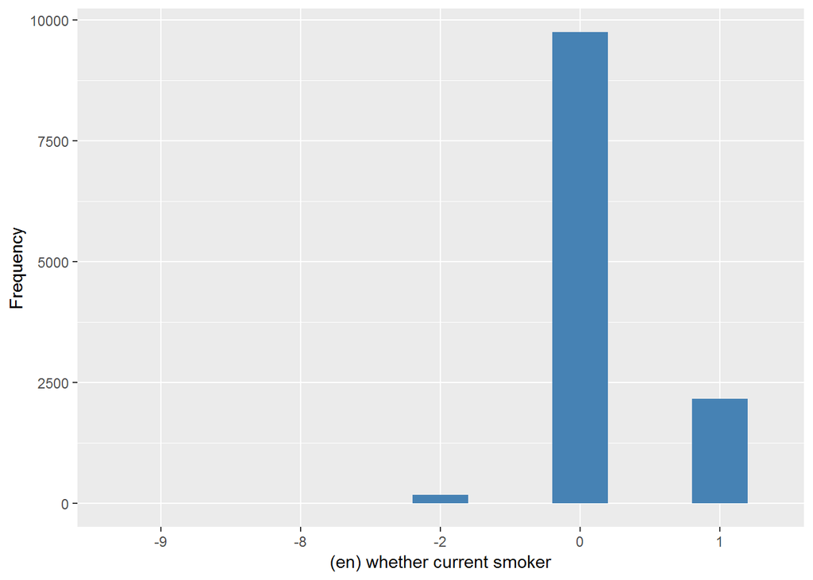

#### 2.1.1.2 Harmonisation algorithm

The harmonized variable is the same than the study-specific variable, but the missing values have to be recoded as follows:

- `-2 into 994`
- `-8 into 998`
- `-9 into 997`

**R script:**

```r
ELSA_ds_w1 <- tibble(id = ELSA_w1$id)
ELSA_ds_w1$current_smoking <- car::recode(ELSA_w1$smoker, "-2 = 994;-8 = 998;-9 = 997 ")
```

#### 2.1.1.3 Statistical description of the new harmonised variable

Current smoker

| Sample size | Missing values |
| --- | --- |
| 12099 | 191 |

Category

|  | 0 | 1 |
| --- | --- | --- |
| Frequency | 9747.00 | 2161.00 |
| Percentage | 80.56 | 17.86 |

Type of missing

|  | 991 | 992 | 993 | 994 | 995 | 996 | 997 | 998 | 999 | NA |
| --- | --- | --- | --- | --- | --- | --- | --- | --- | --- | --- |
| Frequency | 0 | 0 | 0 | 175.00 | 0 | 0 | 5.00 | 11.00 | 0 | 0 |
| Percentage | 0 | 0 | 0 | 1.45 | 0 | 0 | 0.04 | 0.09 | 0 | 0 |

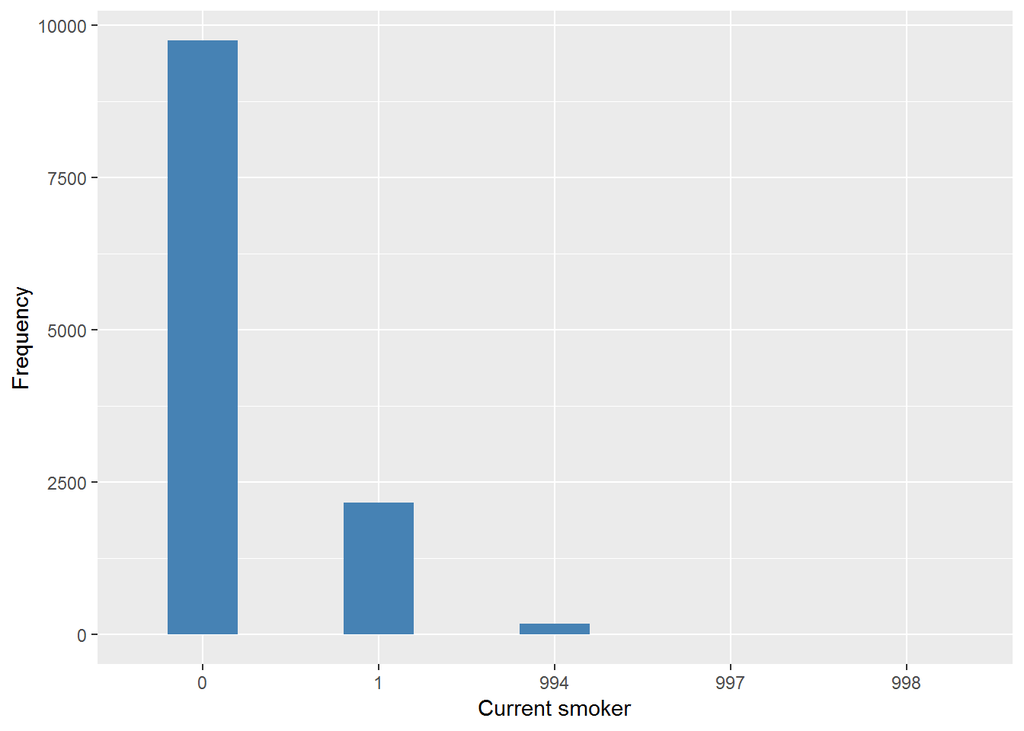

#### 2.1.1.4 Validation

### 2.1.2 Wave 2

#### 2.1.2.1 Study-specific variable description

| **Name** | `smoker` |
| --- | --- |
| **Label** | `whether current smoker` |
| **Table name** | `wave_2_ifs_derived_variables` |
| **Categories:** | `0 = not a current smoker` `1 = current smoker` |
| **Missings:** | `-2 = not asked` `-8 = don't know` `-9 = refuse` |
| **Description** |  |

smoker

| Sample size | Missing values |
| --- | --- |
| 9432 | 6 |

Category

|  | 0 | 1 |
| --- | --- | --- |
| Frequency | 7952.00 | 1474.00 |
| Percentage | 84.31 | 15.63 |

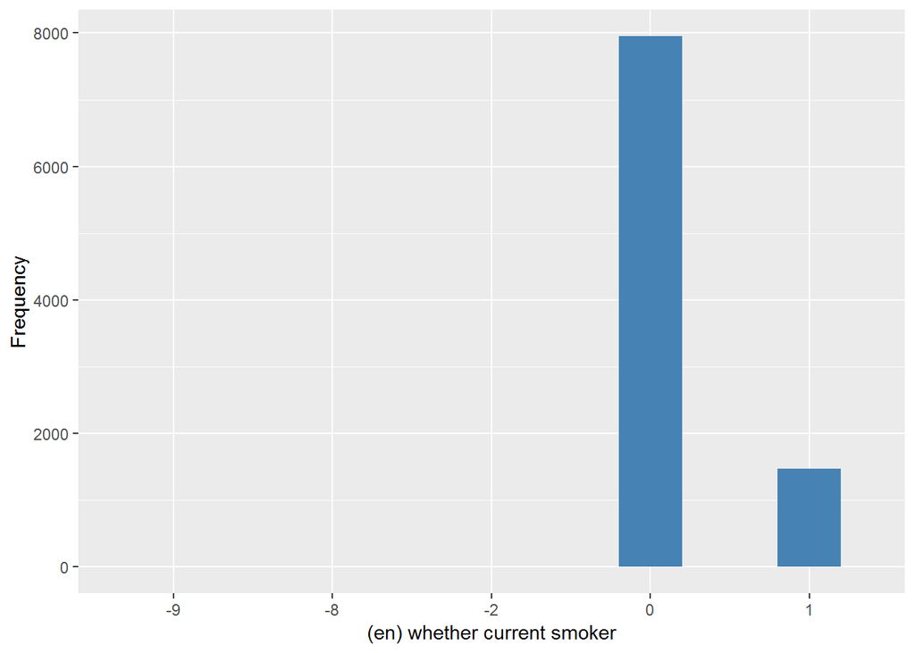

#### 2.1.2.2 Harmonisation algorithm

The harmonized variable is the same than the study-specific variable, but the missing values have to be recoded as follows:

- `-2 into 994`
- `-8 into 998`
- `-9 into 997`

**R script:**

```r
ELSA_ds_w2 <- tibble(id = ELSA_w2$id)
ELSA_ds_w2$current_smoking <- car::recode(ELSA_w2$smoker, "-2 = 994;-8 = 998;-9 = 997 ")
```

#### 2.1.2.3 Statistical description of the new harmonised variable

Current smoker

| Sample size | Missing values |
| --- | --- |
| 9432 | 6 |

Category

|  | 0 | 1 |
| --- | --- | --- |
| Frequency | 7952.00 | 1474.00 |
| Percentage | 84.31 | 15.63 |

Type of missing

|  | 991 | 992 | 993 | 994 | 995 | 996 | 997 | 998 | 999 | NA |
| --- | --- | --- | --- | --- | --- | --- | --- | --- | --- | --- |
| Frequency | 0 | 0 | 0 | 1.00 | 0 | 0 | 1.00 | 4.00 | 0 | 0 |
| Percentage | 0 | 0 | 0 | 0.01 | 0 | 0 | 0.01 | 0.04 | 0 | 0 |

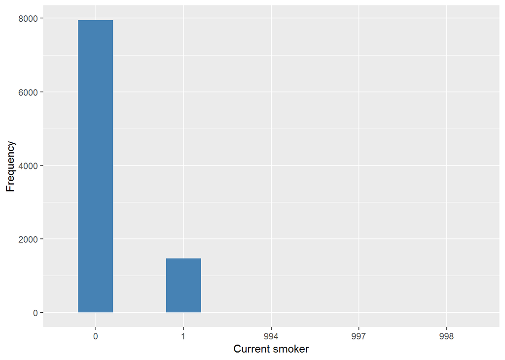

#### 2.1.2.4 Validation

### 2.1.3 Wave 3

#### 2.1.3.1 Study-specific variable description

| **Name** | `smoker` |
| --- | --- |
| **Label** | `whether current smoker` |
| **Table name** | `wave_3_ifs_derived_variables` |
| **Categories:** | `0 = not a current smoker` `1 = current smoker` |
| **Missings:** | `-8 = don't know` `-9 = refuse` |
| **Description** |  |

smoker

| Sample size | Missing values |
| --- | --- |
| 9771 | 5 |

Category

|  | 0 | 1 |
| --- | --- | --- |
| Frequency | 8257.00 | 1509.00 |
| Percentage | 84.51 | 15.44 |

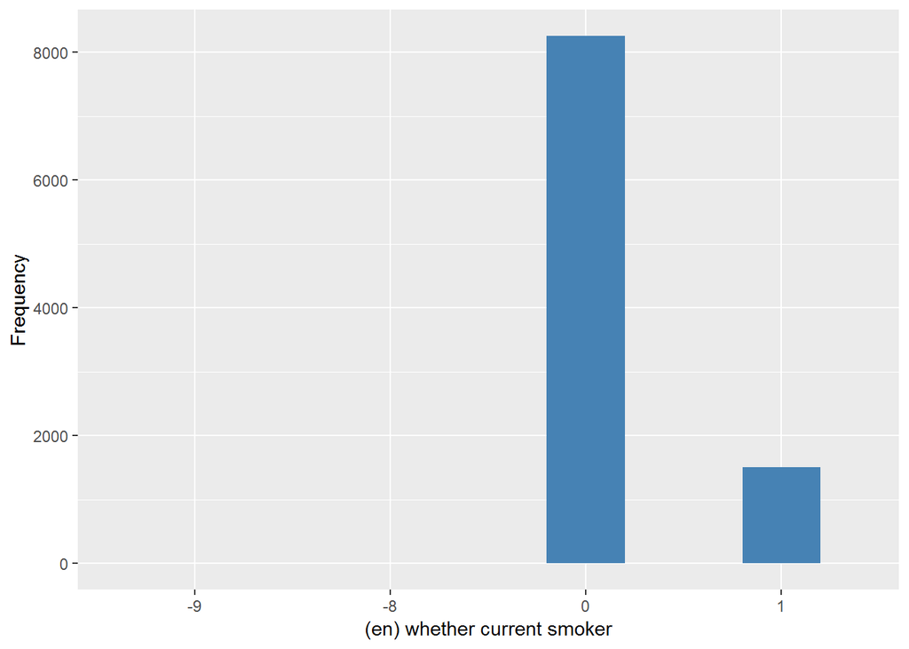

#### 2.1.3.2 Harmonisation algorithm

The harmonized variable is the same than the study-specific variable, but the missing values have to be recoded as follows:

- `-8 into 998`
- `-9 into 997`

**R script:**

```r
ELSA_ds_w3 <- tibble(id = ELSA_w3$id)
ELSA_ds_w3$current_smoking <- car::recode(ELSA_w3$smoker, "-8 = 998;-9 = 997 ")
```

#### 2.1.3.3 Statistical description of the new harmonised variable

Current smoker

| Sample size | Missing values |
| --- | --- |
| 9771 | 5 |

Category

|  | 0 | 1 |
| --- | --- | --- |
| Frequency | 8257.00 | 1509.00 |
| Percentage | 84.51 | 15.44 |

Type of missing

|  | 991 | 992 | 993 | 994 | 995 | 996 | 997 | 998 | 999 | NA |
| --- | --- | --- | --- | --- | --- | --- | --- | --- | --- | --- |
| Frequency | 0 | 0 | 0 | 0 | 0 | 0 | 2.00 | 3.00 | 0 | 0 |
| Percentage | 0 | 0 | 0 | 0 | 0 | 0 | 0.02 | 0.03 | 0 | 0 |

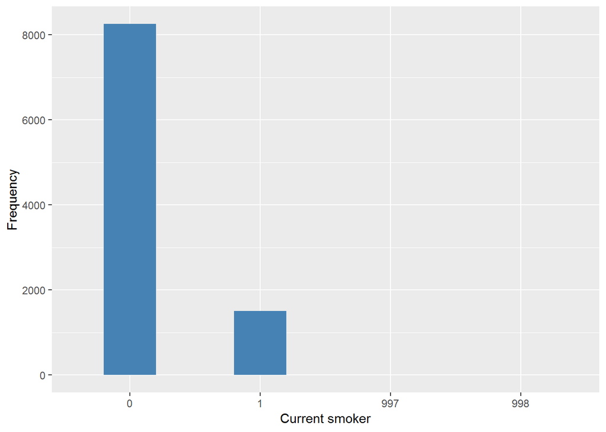

#### 2.1.3.4 Validation

### 2.1.4 Wave 4

#### 2.1.4.1 Study-specific variable description

| **Name** | `smoker` |
| --- | --- |
| **Label** | `whether current smoker` |
| **Table name** | `wave_4_ifs_derived_variables` |
| **Categories:** | `0 = not a current smoker` `1 = current smoker` |
| **Missings:** | `-2 = not asked` `-8 = don't know` `-9 = refuse` |
| **Description** |  |

smoker

| Sample size | Missing values |
| --- | --- |
| 11050 | 223 |

Category

|  | 0 | 1 |
| --- | --- | --- |
| Frequency | 9282 | 1545.00 |
| Percentage | 84 | 13.98 |

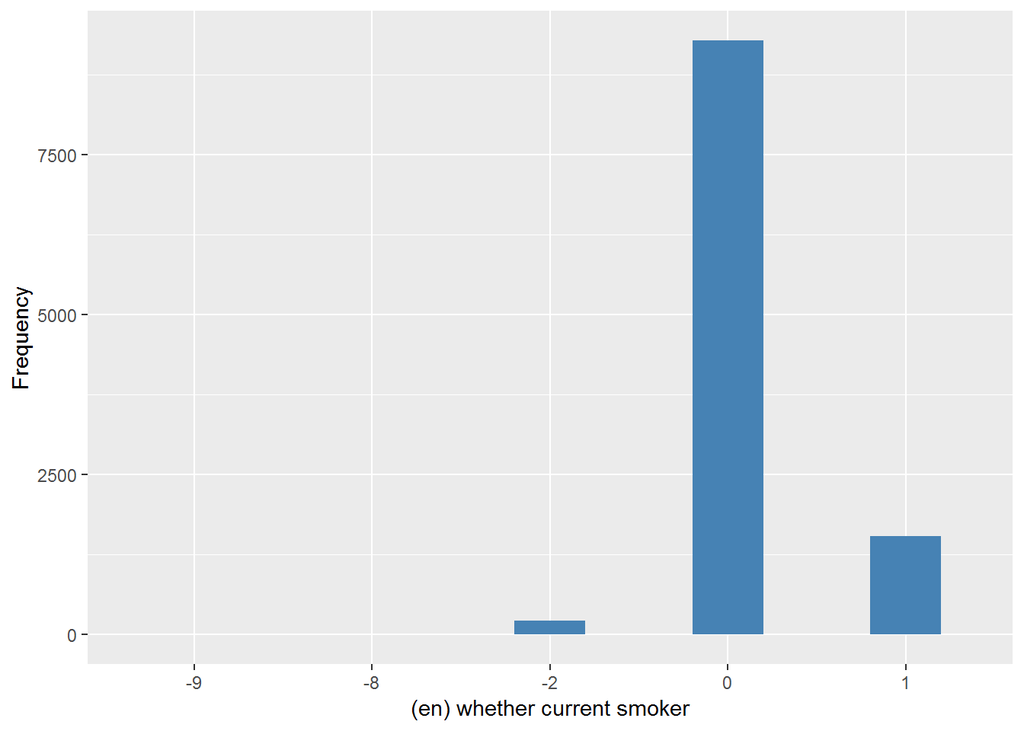

#### 2.1.4.2 Harmonisation algorithm

The harmonized variable is the same than the study-specific variable, but the missing values have to be recoded as follows:

- `-2 into 994`
- `-8 into 998`
- `-9 into 997`

**R script:**

```r
ELSA_ds_w4 <- tibble(id = ELSA_w4$id)
ELSA_ds_w4$current_smoking <- car::recode(ELSA_w4$smoker, "-2 = 994;-8 = 998;-9 = 997 ")
```

#### 2.1.4.3 Statistical description of the new harmonised variable

Current smoker

| Sample size | Missing values |
| --- | --- |
| 11050 | 223 |

Category

|  | 0 | 1 |
| --- | --- | --- |
| Frequency | 9282 | 1545.00 |
| Percentage | 84 | 13.98 |

Type of missing

|  | 991 | 992 | 993 | 994 | 995 | 996 | 997 | 998 | 999 | NA |
| --- | --- | --- | --- | --- | --- | --- | --- | --- | --- | --- |
| Frequency | 0 | 0 | 0 | 214.00 | 0 | 0 | 6.00 | 3.00 | 0 | 0 |
| Percentage | 0 | 0 | 0 | 1.94 | 0 | 0 | 0.05 | 0.03 | 0 | 0 |

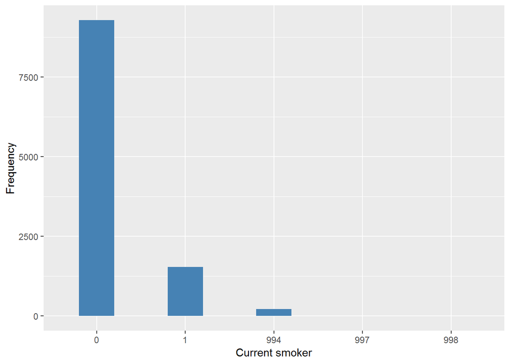

#### 2.1.4.4 Validation

### 2.1.5 Wave 5

#### 2.1.5.1 Study-specific variable description

| **Name** | `smoker` |
| --- | --- |
| **Label** | `whether current smoker` |
| **Table name** | `wave_5_ifs_derived_variables` |
| **Categories:** | `0 = not a current smoker` `1 = current smoker` |
| **Missings:** | `-2 = not asked` `-8 = don't know` `-9 = refuse` |
| **Description** |  |

smoker

| Sample size | Missing values |
| --- | --- |
| 10274 | 306 |

Category

|  | 0 | 1 |
| --- | --- | --- |
| Frequency | 8656.00 | 1312.00 |
| Percentage | 84.25 | 12.77 |

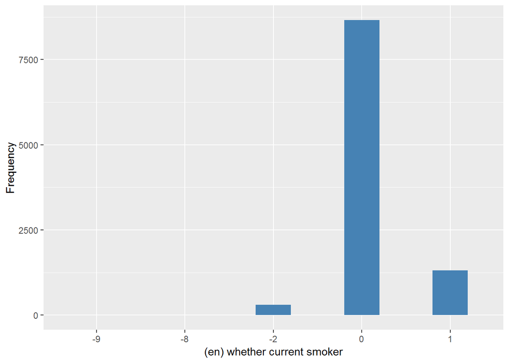

#### 2.1.5.2 Harmonisation algorithm

The harmonized variable is the same than the study-specific variable, but the missing values have to be recoded as follows:

- `-2 into 994`
- `-8 into 998`
- `-9 into 997`

**R script:**

```r
ELSA_ds_w5 <- tibble(id = ELSA_w5$id)
ELSA_ds_w5$current_smoking <- car::recode(ELSA_w5$smoker, "-2 = 994;-8 = 998;-9 = 997 ")
```

#### 2.1.5.3 Statistical description of the new harmonised variable

Current smoker

| Sample size | Missing values |
| --- | --- |
| 10274 | 306 |

Category

|  | 0 | 1 |
| --- | --- | --- |
| Frequency | 8656.00 | 1312.00 |
| Percentage | 84.25 | 12.77 |

Type of missing

|  | 991 | 992 | 993 | 994 | 995 | 996 | 997 | 998 | 999 | NA |
| --- | --- | --- | --- | --- | --- | --- | --- | --- | --- | --- |
| Frequency | 0 | 0 | 0 | 299.00 | 0 | 0 | 4.00 | 3.00 | 0 | 0 |
| Percentage | 0 | 0 | 0 | 2.91 | 0 | 0 | 0.04 | 0.03 | 0 | 0 |

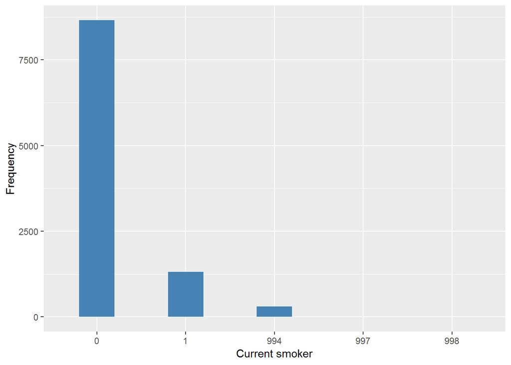

#### 2.1.5.4 Validation

### 2.1.6 Wave 6

#### 2.1.6.1 Study-specific variable description

| **Name** | `smoker` |
| --- | --- |
| **Label** | `whether current smoker` |
| **Table name** | `wave_6_ifs_derived_variables` |
| **Categories:** | `0 = not a current smoker` `1 = current smoker` |
| **Missings:** | `-8 = don't know` `-9 = refuse` |
| **Description** |  |

smoker

| Sample size | Missing values |
| --- | --- |
| 10601 | 5 |

Category

|  | 0 | 1 |
| --- | --- | --- |
| Frequency | 9280.00 | 1316.00 |
| Percentage | 87.54 | 12.41 |

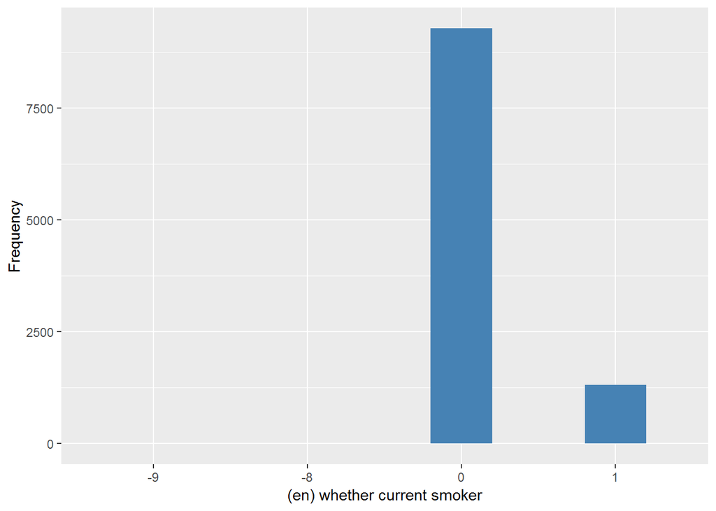

#### 2.1.6.2 Harmonisation algorithm

The harmonized variable is the same than the study-specific variable, but the missing values have to be recoded as follows:

- `-8 into 998`
- `-9 into 997`

**R script:**

```r
ELSA_ds_w6 <- tibble(id = ELSA_w6$id)
ELSA_ds_w6$current_smoking <- car::recode(ELSA_w6$smoker, "-8 = 998;-9 = 997 ")
```

#### 2.1.6.3 Statistical description of the new harmonised variable

Current smoker

| Sample size | Missing values |
| --- | --- |
| 10601 | 5 |

Category

|  | 0 | 1 |
| --- | --- | --- |
| Frequency | 9280.00 | 1316.00 |
| Percentage | 87.54 | 12.41 |

Type of missing

|  | 991 | 992 | 993 | 994 | 995 | 996 | 997 | 998 | 999 | NA |
| --- | --- | --- | --- | --- | --- | --- | --- | --- | --- | --- |
| Frequency | 0 | 0 | 0 | 0 | 0 | 0 | 3.00 | 2.00 | 0 | 0 |
| Percentage | 0 | 0 | 0 | 0 | 0 | 0 | 0.03 | 0.02 | 0 | 0 |

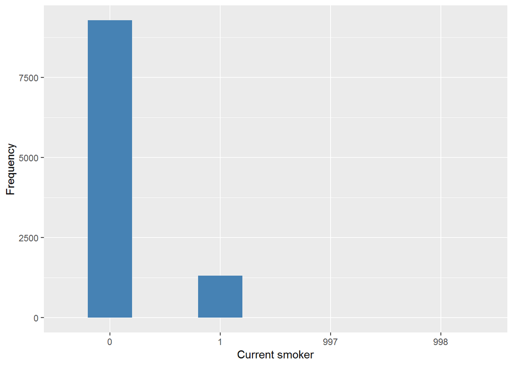

#### 2.1.6.4 Validation

### 2.1.7 Wave 7

#### 2.1.7.1 Study-specific variable description

| **Name** | `smoker` |
| --- | --- |
| **Label** | `whether current smoker` |
| **Table name** | `wave7_dv` |
| **Categories:** | `0 = not a current smoker` `1 = current smoker` |
| **Missings:** | `-8 = don't know` `-9 = refuse` |
| **Description** |  |

smoker

| Sample size | Missing values |
| --- | --- |
| 9666 | 2 |

Category

|  | 0 | 1 |
| --- | --- | --- |
| Frequency | 8570.00 | 1094.00 |
| Percentage | 88.66 | 11.32 |

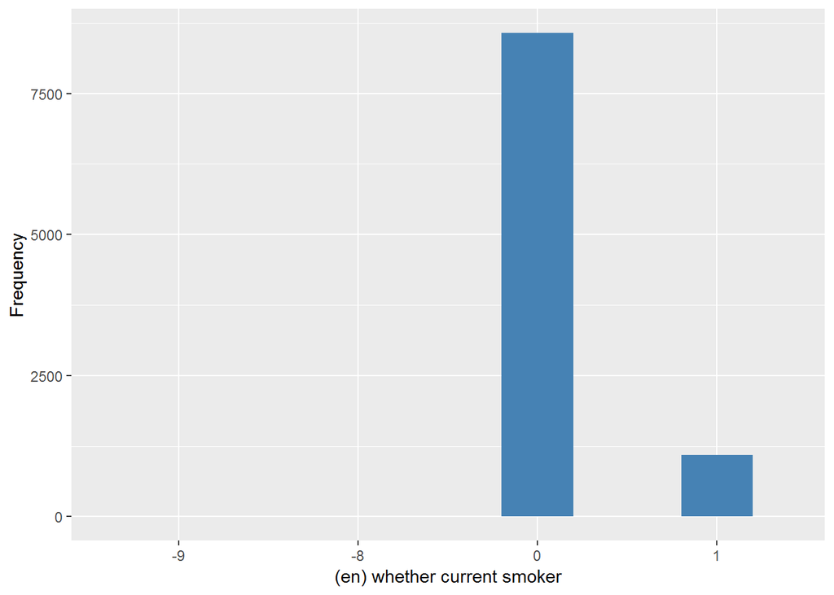

#### 2.1.7.2 Harmonisation algorithm

The harmonized variable is the same than the study-specific variable, but the missing values have to be recoded as follows:

- `-8 into 998`
- `-9 into 997`

**R script:**

```r
ELSA_ds_w7 <- tibble(id = ELSA_w7$id)
ELSA_ds_w7$current_smoking <- car::recode(ELSA_w7$smoker, "-8 = 998;-9 = 997 ")
```

#### 2.1.7.3 Statistical description of the new harmonised variable

Current smoker

| Sample size | Missing values |
| --- | --- |
| 9666 | 2 |

Category

|  | 0 | 1 |
| --- | --- | --- |
| Frequency | 8570.00 | 1094.00 |
| Percentage | 88.66 | 11.32 |

Type of missing

|  | 991 | 992 | 993 | 994 | 995 | 996 | 997 | 998 | 999 | NA |
| --- | --- | --- | --- | --- | --- | --- | --- | --- | --- | --- |
| Frequency | 0 | 0 | 0 | 0 | 0 | 0 | 1.00 | 1.00 | 0 | 0 |
| Percentage | 0 | 0 | 0 | 0 | 0 | 0 | 0.01 | 0.01 | 0 | 0 |

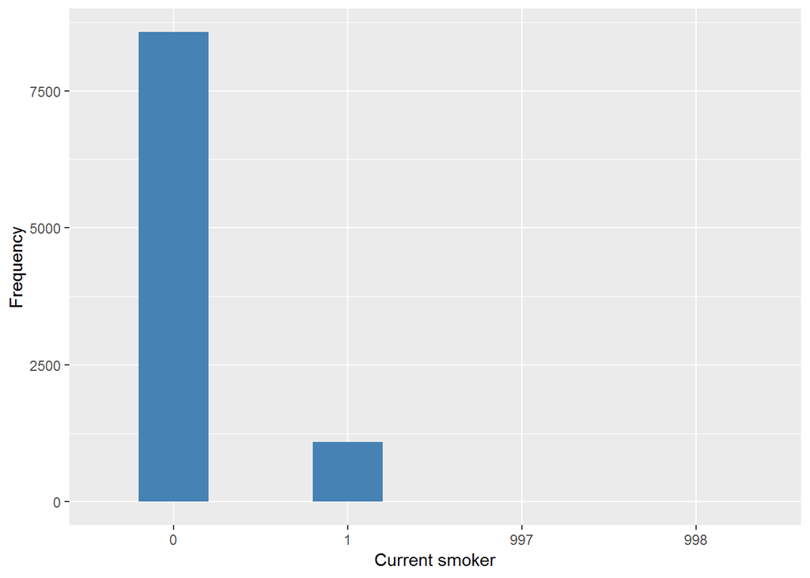

#### 2.1.7.4 Validation

## 2.2 Summary of descriptive statistics of the harmonised variable accross populations and waves

Two tables are generated:

1. Percentages of categories in each harmonised variable.
2. Frequencies and percentages of individuals with different trajectories. To avoid too large table, Only trajectories with percentages larger than 0.3 are shown.

```r
t.hds <- frq(l.hds[[1]][2])[[1]][, c(1, 2)]
for (i in seq_along(l.hds)) {
    t.hds[2 + i] <- frq(l.hds[[i]][2])[[1]][, 4]
}
t.hds[13, ] <- c("n", "sample size", sapply(l.hds, function(wave) length(wave[[1]])))
names(t.hds) <- c("val", "label", names(l.hds))
kable(t.hds)
```

| val | label | w1 | w2 | w3 | w4 | w5 | w6 | w7 |
| --- | --- | --- | --- | --- | --- | --- | --- | --- |
| 0 | No | 80.56 | 84.31 | 84.51 | 84 | 84.25 | 87.54 | 88.66 |
| 1 | Yes | 17.86 | 15.63 | 15.44 | 13.98 | 12.77 | 12.41 | 11.32 |
| 991 | CAPI interviewer error | 0 | 0 | 0 | 0 | 0 | 0 | 0 |
| 992 | Impute | 0 | 0 | 0 | 0 | 0 | 0 | 0 |
| 993 | Disable to measure | 0 | 0 | 0 | 0 | 0 | 0 | 0 |
| 994 | Not attempt not done | 1.45 | 0.01 | 0 | 1.94 | 2.91 | 0 | 0 |
| 995 | Does not answer | 0 | 0 | 0 | 0 | 0 | 0 | 0 |
| 996 | Not applicable | 0 | 0 | 0 | 0 | 0 | 0 | 0 |
| 997 | Refuse | 0.04 | 0.01 | 0.02 | 0.05 | 0.04 | 0.03 | 0.01 |
| 998 | Do not know | 0.09 | 0.04 | 0.03 | 0.03 | 0.03 | 0.02 | 0.01 |
| 999 | Missing | 0 | 0 | 0 | 0 | 0 | 0 | 0 |
| NA | NA | 0 | 0 | 0 | 0 | 0 | 0 | 0 |
| n | sample size | 12099 | 9432 | 9771 | 11050 | 10274 | 10601 | 9666 |

```r
dbb <- get(paste0("ELSA_m_ds_", names(l.hds)[1]))[, c("id", "current_smoking")]
for (ind in 2:length(l.hds)) {
    dbb <- merge(dbb, get(paste0("ELSA_m_ds_", names(l.hds)[ind]))[, c("id",
        "current_smoking")], by = "id", suffixes = c("", paste0(".", names(l.hds)[ind])),
        all = T)
}
names(dbb) <- c("id", names(l.hds))

v.dbb <- dbb[, 2]
for (ind in 2:length(l.hds)) {
    v.dbb <- paste(v.dbb, dbb[, ind + 1], sep = "")
}
f.dbb <- frq(v.dbb)[[1]][, c(1, 2, 4)]
kable(f.dbb[f.dbb[, 3] >= 0.3, ])
```

|  | val | frq | raw.prc |
| --- | --- | --- | --- |
| 1 | 0000000 | 3568 | 19.30 |
| 3 | 000000NA | 523 | 2.83 |
| 7 | 00000NANA | 349 | 1.89 |
| 15 | 0000NA00 | 77 | 0.42 |
| 18 | 0000NANANA | 505 | 2.73 |
| 27 | 000NA000 | 109 | 0.59 |
| 29 | 000NA00NA | 57 | 0.31 |
| 39 | 000NANANANA | 747 | 4.04 |
| 52 | 00NA0000 | 84 | 0.45 |
| 73 | 00NANANANANA | 984 | 5.32 |
| 109 | 0NA00000 | 80 | 0.43 |
| 123 | 0NA0NANANANA | 85 | 0.46 |
| 127 | 0NANA0000 | 55 | 0.30 |
| 146 | 0NANANANANANA | 1588 | 8.59 |
| 147 | 1000000 | 82 | 0.44 |
| 268 | 1111111 | 254 | 1.37 |
| 269 | 111111NA | 63 | 0.34 |
| 277 | 1111NANANA | 73 | 0.39 |
| 294 | 111NANANANA | 116 | 0.63 |
| 322 | 11NANANANANA | 227 | 1.23 |
| 371 | 1NANANANANANA | 416 | 2.25 |
| 412 | NANA00000 | 662 | 3.58 |
| 413 | NANA0000NA | 82 | 0.44 |
| 415 | NANA000NANA | 59 | 0.32 |
| 423 | NANA00NANANA | 96 | 0.52 |
| 444 | NANA0NANANANA | 227 | 1.23 |
| 468 | NANA11111 | 105 | 0.57 |
| 496 | NANA1NANANANA | 88 | 0.48 |
| 497 | NANANA0000 | 1358 | 7.34 |
| 499 | NANANA000NA | 194 | 1.05 |
| 504 | NANANA00NANA | 131 | 0.71 |
| 517 | NANANA0NANANA | 271 | 1.47 |
| 530 | NANANA1111 | 158 | 0.85 |
| 543 | NANANA1NANANA | 63 | 0.34 |
| 544 | NANANANA000 | 69 | 0.37 |
| 556 | NANANANANA00 | 831 | 4.49 |
| 558 | NANANANANA0NA | 236 | 1.28 |
| 560 | NANANANANA11 | 147 | 0.80 |
| 561 | NANANANANA1NA | 56 | 0.30 |
| 562 | NANANANANANA0 | 421 | 2.28 |
| 563 | NANANANANANA1 | 102 | 0.55 |
| 564 | NANANANANANANA | 154 | 0.83 |

# 3 Quality estimation